# Reunión Cristina 22/05

Gazze Simón Pedro

2026-05-21

## Resúmen

Intentar identificar los aportes de los jugadores en el rendimientos de sus equipos.

$y$ = puntos por posesión

$\textbf{X}_{off}$ = Variables indicadores que reflejan la presencia ofensiva de los jugadores (1 si estaba en la cancha, 0 si no estaba)

$\textbf{X}_{def}$ = Variables indicadores que reflejan la presencia defensiva de los jugadores (-1 si estaba en la cancha, 0 si no estaba)

**Modelos normales**

$$y_i = \beta_0 + \sum_{j=1}^{K}
\beta^o_j x^o_{ji} + \sum_{j=1}^{K} \beta^d_j x^d_{ji} +
e_i$$

Estimación de los parámetros mediante técnicas de regularización:

Ridge:$S^*= \sum_{i=1}^n (y_i-\mu_i)^2 + \lambda \sum_{j=1}^p\beta_j^2=S+\lambda \sum_{j=1}^p\beta_j^2$

Lasso:$S^*= \sum_{i=1}^n (y_i-\mu_i)^2 + \lambda \sum_{j=1}^p|\beta_j|=S+\lambda \sum_{j=1}^p\ |\beta_j|$

Elastic Net:$S^*= \sum_{i=1}^n (y_i-\mu_i)^2 + \lambda [\alpha\sum_{j=1}^p|\beta_j|+(1-\alpha)\sum_{j=1}^p\beta_j^2]$

Los coeficientes que acompañan a las variables explicativas son las métricas RAPM, las cuales dan indicios del aporte que realiza cada jugador

**Modelos multinomiales**:

Se toman como categorías nominales a 0,1,2 y 3 o más puntos en la posesión:

$$logit(\pi_{ic}) =
log(\frac{\pi_{ic}}{\pi_{i0}})=\beta_{0c} + \sum_{j=1}^{K} \beta^o_{jc}
x^o_{ji} + \sum_{j=1}^{K} \beta^d_{jc} x^d_{ji}\quad \text{con } c=
\{1,2, 3+\}$$

Esimación por Máxima Verosimilitud y técnicas de regularización:

Ridge:$L^*_m(\boldsymbol{\beta},\boldsymbol{y})=\sum_{j=1}^cy_{ij}log(\pi_{ij}) + \lambda \sum_{j=1}^p\beta_j^2=S+\lambda \sum_{j=1}^p\beta_j^2$

Lasso:$L^*_m(\boldsymbol{\beta},\boldsymbol{y})=\sum_{j=1}^cy_{ij}log(\pi_{ij}) + \lambda \sum_{j=1}^p|\beta_j|=S+\lambda \sum_{j=1}^p\ |\beta_j|$

Elastic Net:$L^*_m(\boldsymbol{\beta},\boldsymbol{y})=\sum_{j=1}^cy_{ij}log(\pi_{ij}) + \lambda \sum_{j=1}^p[\alpha\sum_{j=1}^p|\beta_j|+(1-\alpha)\sum_{j=1}^p\beta_j^2]$

Como en este tipo de modelos no tenemos una métrica que sintetice el aporte de los jugadores a la cantidad de puntos esperados, pero si podemos calcular las probabilidades de anotar para cada categoría, se obtiene la siguiente métrica:

$$EPTS_k^r=
\pi^r_{k1}+2\pi_{k2}^r+3,03\pi_{k3}^r, \quad r \in \{o,d\}$$

Luego en Lasso multinomial performance indicators for in‑play basketball data proponen una métrica “superadora” que tiene en cuenta participación del jugador a lo largo de la temporada, si juega muy poco lleva su coeficiente a un valor “promedio”.

Para combatir a los jugadores con pocos minutos que presentan coeficientes extremos.

$$\begin{aligned}
wEPTS_k^{r} &= E(Pts_i \mid \boldsymbol{X}_{i\setminus{k}}^{r} =
\boldsymbol{0},\, \boldsymbol{X}_i^{\,\bar{r}} = \boldsymbol{0},\, T_i =
t_k) \\[6pt]
&= P(X_{ik}^{r} \ne 0 \mid T_i = t_k) \, E(Pts_i \mid X_{ik}^{r} \ne
0,\boldsymbol{X}_{i\setminus{k}}^{r} = \boldsymbol{0},\,
\boldsymbol{X}_i^{\,\bar{r}} = \boldsymbol{0}) \\[6pt]
&\quad + P(X_{ik}^{r} = 0 \mid T_i = t_k) \, E(Pts_i \mid X_{ik}^{r}
\ne 0,\boldsymbol{X}_{i\setminus{k}}^{r} = \boldsymbol{0},\,
\boldsymbol{X}_i^{\,\bar{r}} = \boldsymbol{0}) \\[6pt]
&= W_k^{r} \, EPTS_k^{r} + (1 - W_k^{r}) \, EPTS_0
\end{aligned}$$
Donde $W_k$ es la proporción de posesiones en las que participó el jugador dentro de su equipo

$$\hat{W}_k^{r} =
\frac{n_k^{r}}{n_{t_k}^{r}}
=
\frac{\sum_{i=1}^{n} \mathcal{I}(X_{ik}^{r} \ne 0)}
{\sum_{i=1}^{n} \mathcal{I}(T_i^{r} = t_k)}.$$

## Comparación de modelos

Basados en este enfoque realizado por Damoulaki en *Lasso multinomial performance indicators for in‑play basketball data*:

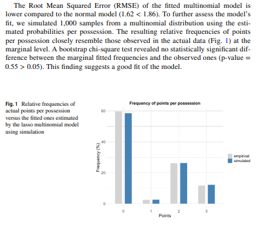

Se proponen ambas estrategias de evaluación.

### Modelo Normal vs Modelo Multinomial

Con el objetivo de evaluar el desempeño predictivo de los modelos considerados, se comparó el modelo de regresión normal tradicional con el modelo multinomial propuesto utilizando como criterio principal el error cuadrático medio (, RMSE).

En el enfoque clásico basado en regresión normal, la variable respuesta corresponde a los puntos anotados en cada posesión y se modela como una variable continua:

$$Y_i \sim N(\mu_i,\sigma^2),$$

donde $Y_i$ representa los puntos anotados en la posesión $i$, mientras que $\mu_i$ corresponde al valor esperado estimado por el modelo.

Por otro lado, el modelo multinomial considera explícitamente la naturaleza discreta de la variable respuesta. En este caso, para cada posesión $i$, el modelo estima las probabilidades:

$$P(Y_i = k)=\pi_{ik},$$

con

$$k \in \{0,1,2,3\},$$

donde $\pi_{ik}$ representa la probabilidad estimada de anotar $k$ puntos en la posesión $i$.

Como no contamos con un valor de $y$ predicho para calcular el RMSE es posible, a partir de sendas probabilidades estimadas, obtener el valor esperado de puntos por posesión:

$$EPTS = E(Y_i)=
0\pi_{i0}
+1\pi_{i1}
+2\pi_{i2}
+3.03\pi_{i3}.$$

De esta forma, tanto el modelo normal como el multinomial producen una **predicción continua** del número esperado de puntos por posesión, permitiendo comparar ambos enfoques mediante el RMSE:

$$RMSE=
\sqrt{
\frac{1}{n}
\sum_{i=1}^{n}
(y_i-\hat y_i)^2
},$$

donde $y_i$ representa el valor observado y $\hat y_i$ el valor predicho por el modelo.

```
## RMSE Ridge Normal (Con todos los datos): 1.183456
```

```
## RMSE Ridge Normal (Cross-Validation): 1.405208
```

```
## RMSE Lasso Normal (Con todos los datos): 1.183418
```

```
## RMSE Lasso Normal (Cross-Validation): 1.405618
```

```
## RMSE Ridge Multinomial: 1.182701
```

```
## RMSE Lasso Multinomial: 1.182915
```

En el trabajo de referencia, el modelo multinomial obtuvo un RMSE (=1.62) menor que el modelo normal (1.86), sugiriendo un mejor ajuste a los datos observados.

En nuestro trabajo la diferencia es mucho menor, presentandose valores prácticamente igual (RMSE Normal = 1.1834564 vs RMSE multinomial = 1.1827014). Igualmente ambos modelos multinomiales presentan valores levemente menores.

Tener en cuenta que este valor de RMSE no es el obtenido con los datos de test (obtenidos al realizar validación cruzada), ya que no contamos con esta info en el modelo multinomial (utiliza la Deviance para cv).

### Bondad de ajuste del modelo multinomial

Además de comparar los modelos mediante RMSE, se realizó una validación adicional utilizando simulaciones generadas a partir del modelo multinomial ajustado.

Para cada posesión $i$, el modelo estima un vector de probabilidades:

$$(\pi_{i0},\pi_{i1},\pi_{i2},\pi_{i3}),$$

que representa las probabilidades de anotar $0$, $1$, $2$ o $3$ puntos, respectivamente.

Posteriormente, para cada posesión se genera aleatoriamente un resultado según dichas probabilidades. Por ejemplo, si para una posesión determinada el modelo estima:

$$(0.58,0.03,0.27,0.12),$$

entonces el valor simulado para dicha posesión será:

$$Y_i^{sim}=
\begin{cases}
0 & \text{con probabilidad } 0.58, \\
1 & \text{con probabilidad } 0.03, \\
2 & \text{con probabilidad } 0.27, \\
3 & \text{con probabilidad } 0.12.
\end{cases}$$

Este procedimiento se repite para todas las posesiones del conjunto de datos, obteniendo así un conjunto completo de posesiones simuladas. Luego, el proceso completo se replica múltiples veces (en este caso, 1000 simulaciones independientes).

El objetivo de esta metodología es evaluar si el modelo multinomial es capaz de reproducir adecuadamente la distribución observada de puntos por posesión. Para ello, se comparan las frecuencias relativas simuladas y observadas de cada categoría de anotación.

Usaremos el modelo de regresión logística multinomial ajustado con Ridge, ya que brindó el menor RMSE entre los 2 modelos:

```r
#Genero 1000 simulaciones de toda la temporada para mi variable respuesta
simulaciones <- replicate(
  1000,
  apply(
    probs_mat, #probs_mat tiene las probabilidades estimadas con ridge de cada una de las posesiones (filas) de toda la temporada
    1,
    function(p){
      sample( #generamos las simulaciones
        x = valores,
        size = 1,
        prob = p
      )
    }
  )
)

#Una vez terminadas las simulaciones, obtenemos una base con la cantidad de posesiones en la temporada como filas y 1000 columnas que representan a cada simulación. Las celdas contienen a la respuesta estimada en base a las probabilidades.

# A continuación, calculo las proporciones de 0, 1, 2 y 3+ en la temporada para cada columna.

freq_sim <- apply(
  simulaciones,
  2,
  function(x){
    prop.table(table(factor(x, levels = valores)))
  }
)

#Calculo la proporción total de 0, 1, 2 y 3+ para todas las simulaciones

freq_sim = rowMeans(freq_sim)
```

```
## [1] "Proporciones simuladas 0.532960255863539 0.0406713859275053 0.28422667803838 0.142141680170576"
```

```
## [1] "Proporciones empíricas 0.53289552238806 0.040682302771855 0.284349680170576 0.14207249466951"
```

Una vez obtenidas las 1000 simulaciones, mostramos la proporción de 0, 1, 2 y 3+ obtenidas en dichas muestras:

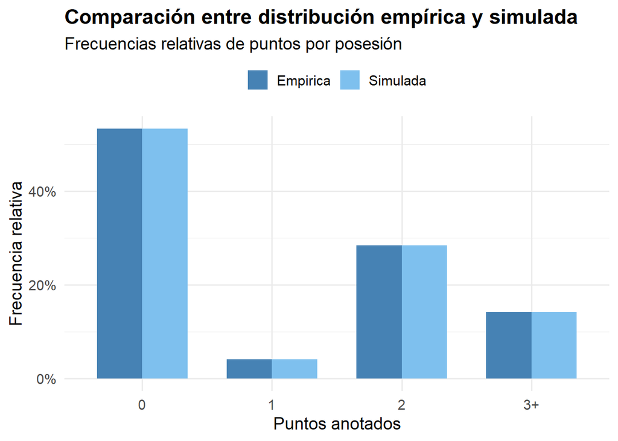

Distribuciones prácticamente iguales (sospechosamente iguales).

### Criterios de validación externa

Para evaluar los distintos rankings, se procederá a compararlos en base a distintos criterios de validación externa. Estos criterios son “objetivos” y se definen con información no utilizada en los modelos. Los criterios son:

1. **Pocos minutos**: porcentaje de jugadores top-50 del ranking que pertenecen al grupo de los 50 jugadores con menos minutos jugados. Un buen modelo debería penalizar a estos jugadores.
2. **Titulares**: porcentaje de jugadores top-50 del ranking que son titulares (los 6 con más minutos por equipo).
3. **Galardones**: porcentaje de jugadores top-50 del ranking que recibieron al menos un galardón o estuvieron ternados durante la temporada. Contamos como jugadores galardonados a los que estuvieron presentes en las ternas (3 por terna) de MVP, Mejor jugador Nacional, Mejor jugador extranjero, Mejor jugador defensivo, Mejor sexto hombre y Jugador con mayor progresión. También se incluyeron a todos los jugadores que fueron incluidos en al menos 1 equipo de la semana a lo largo de la temporada.
4. **Box score - Top 50**: porcentaje de jugadores top-50 en distintas estadísticas de box score que aparecen en el top-50 del ranking.

##### Criterio 1: Jugadores con pocos minutos

Pocos minutos — rankings ofensivos

| modelo | coincidencias | porcentaje |
| --- | --- | --- |
| RAPM - Ridge | 6 | 12 |
| RAPM - Lasso | 6 | 12 |
| RAPM - Elastic Net | 3 | 6 |
| EPTS - Ridge | 4 | 8 |
| EPTS - Lasso | 1 | 2 |
| EPTS - Elastic Net | 1 | 2 |
| wEPTS - Ridge | 0 | 0 |
| wEPTS - Lasso | 1 | 2 |
| wEPTS - Elastic Net | 1 | 2 |

Pocos minutos — rankings defensivos

| modelo | coincidencias | porcentaje |
| --- | --- | --- |
| RAPM - Ridge | 13 | 26 |
| RAPM - Lasso | 8 | 16 |
| RAPM - Elastic Net | 6 | 12 |
| EPTS - Ridge | 8 | 16 |
| EPTS - Lasso | 4 | 8 |
| EPTS - Elastic Net | 4 | 8 |
| wEPTS - Ridge | 2 | 4 |
| wEPTS - Lasso | 4 | 8 |
| wEPTS - Elastic Net | 4 | 8 |

##### Criterio 2: Titulares

Titulares — rankings ofensivos

| modelo | coincidencias | porcentaje |
| --- | --- | --- |
| RAPM - Ridge | 28 | 56 |
| RAPM - Lasso | 32 | 64 |
| RAPM - Elastic Net | 35 | 70 |
| EPTS - Ridge | 32 | 64 |
| EPTS - Lasso | 33 | 66 |
| EPTS - Elastic Net | 33 | 66 |
| wEPTS - Ridge | 41 | 82 |
| wEPTS - Lasso | 34 | 68 |
| wEPTS - Elastic Net | 34 | 68 |

Titulares — rankings defensivos

| modelo | coincidencias | porcentaje |
| --- | --- | --- |
| RAPM - Ridge | 22 | 44 |
| RAPM - Lasso | 27 | 54 |
| RAPM - Elastic Net | 30 | 60 |
| EPTS - Ridge | 29 | 58 |
| EPTS - Lasso | 34 | 68 |
| EPTS - Elastic Net | 34 | 68 |
| wEPTS - Ridge | 37 | 74 |
| wEPTS - Lasso | 34 | 68 |
| wEPTS - Elastic Net | 35 | 70 |

##### Criterio 3: Galardones

Galardones — rankings ofensivos

| modelo | coincidencias | porcentaje |
| --- | --- | --- |
| RAPM - Ridge | 26 | 52 |
| RAPM - Lasso | 22 | 44 |
| RAPM - Elastic Net | 24 | 48 |
| EPTS - Ridge | 26 | 52 |
| EPTS - Lasso | 26 | 52 |
| EPTS - Elastic Net | 26 | 52 |
| wEPTS - Ridge | 29 | 58 |
| wEPTS - Lasso | 27 | 54 |
| wEPTS - Elastic Net | 27 | 54 |

Galardones — rankings defensivos

| modelo | coincidencias | porcentaje |
| --- | --- | --- |
| RAPM - Ridge | 18 | 36 |
| RAPM - Lasso | 16 | 32 |
| RAPM - Elastic Net | 19 | 38 |
| EPTS - Ridge | 22 | 44 |
| EPTS - Lasso | 26 | 52 |
| EPTS - Elastic Net | 26 | 52 |
| wEPTS - Ridge | 25 | 50 |
| wEPTS - Lasso | 26 | 52 |
| wEPTS - Elastic Net | 27 | 54 |

##### Criterio 4: Box Score — Top 50

Box score — rankings ofensivos

| modelo | variable | coincidencias | porcentaje |
| --- | --- | --- | --- |
| RAPM - Ridge | total_Asistencias | 12 | 24 |
| RAPM - Lasso | total_Asistencias | 16 | 32 |
| RAPM - Elastic Net | total_Asistencias | 15 | 30 |
| EPTS - Ridge | total_Asistencias | 13 | 26 |
| EPTS - Lasso | total_Asistencias | 14 | 28 |
| EPTS - Elastic Net | total_Asistencias | 14 | 28 |
| wEPTS - Ridge | total_Asistencias | 19 | 38 |
| wEPTS - Lasso | total_Asistencias | 14 | 28 |
| wEPTS - Elastic Net | total_Asistencias | 15 | 30 |
| RAPM - Ridge | total_Puntos | 15 | 30 |
| RAPM - Lasso | total_Puntos | 16 | 32 |
| RAPM - Elastic Net | total_Puntos | 19 | 38 |
| EPTS - Ridge | total_Puntos | 18 | 36 |
| EPTS - Lasso | total_Puntos | 22 | 44 |
| EPTS - Elastic Net | total_Puntos | 22 | 44 |
| wEPTS - Ridge | total_Puntos | 24 | 48 |
| wEPTS - Lasso | total_Puntos | 22 | 44 |
| wEPTS - Elastic Net | total_Puntos | 23 | 46 |
| RAPM - Ridge | total_ReboteOfensivo | 13 | 26 |
| RAPM - Lasso | total_ReboteOfensivo | 12 | 24 |
| RAPM - Elastic Net | total_ReboteOfensivo | 18 | 36 |
| EPTS - Ridge | total_ReboteOfensivo | 17 | 34 |
| EPTS - Lasso | total_ReboteOfensivo | 16 | 32 |
| EPTS - Elastic Net | total_ReboteOfensivo | 16 | 32 |
| wEPTS - Ridge | total_ReboteOfensivo | 21 | 42 |
| wEPTS - Lasso | total_ReboteOfensivo | 16 | 32 |
| wEPTS - Elastic Net | total_ReboteOfensivo | 17 | 34 |

Box score — rankings defensivos

| modelo | variable | coincidencias | porcentaje |
| --- | --- | --- | --- |
| RAPM - Ridge | total_ReboteDefensivo | 9 | 18 |
| RAPM - Lasso | total_ReboteDefensivo | 12 | 24 |
| RAPM - Elastic Net | total_ReboteDefensivo | 14 | 28 |
| EPTS - Ridge | total_ReboteDefensivo | 11 | 22 |
| EPTS - Lasso | total_ReboteDefensivo | 13 | 26 |
| EPTS - Elastic Net | total_ReboteDefensivo | 13 | 26 |
| wEPTS - Ridge | total_ReboteDefensivo | 15 | 30 |
| wEPTS - Lasso | total_ReboteDefensivo | 13 | 26 |
| wEPTS - Elastic Net | total_ReboteDefensivo | 13 | 26 |
| RAPM - Ridge | total_Recuperaciones | 11 | 22 |
| RAPM - Lasso | total_Recuperaciones | 14 | 28 |
| RAPM - Elastic Net | total_Recuperaciones | 15 | 30 |
| EPTS - Ridge | total_Recuperaciones | 14 | 28 |
| EPTS - Lasso | total_Recuperaciones | 18 | 36 |
| EPTS - Elastic Net | total_Recuperaciones | 18 | 36 |
| wEPTS - Ridge | total_Recuperaciones | 19 | 38 |
| wEPTS - Lasso | total_Recuperaciones | 18 | 36 |
| wEPTS - Elastic Net | total_Recuperaciones | 19 | 38 |
| RAPM - Ridge | total_TaponCometido | 12 | 24 |
| RAPM - Lasso | total_TaponCometido | 14 | 28 |
| RAPM - Elastic Net | total_TaponCometido | 14 | 28 |
| EPTS - Ridge | total_TaponCometido | 15 | 30 |
| EPTS - Lasso | total_TaponCometido | 12 | 24 |
| EPTS - Elastic Net | total_TaponCometido | 12 | 24 |
| wEPTS - Ridge | total_TaponCometido | 13 | 26 |
| wEPTS - Lasso | total_TaponCometido | 12 | 24 |
| wEPTS - Elastic Net | total_TaponCometido | 12 | 24 |

La métrica EPTS ponderada por cantidad de posesiones y estimada con Ridge fue la que presentó mejores valores en la mayoría de estos criterios.